# Life Expectancy and GDP

By Nicholas Quisler

# Introduction

This project investigates probable correlations between the economic output of a country, gross domestic product (USD), and the life expectancy at birth of its citizens.

Here are a few questions this project seeks to answer:

- Has life expectancy increased over time in the six nations?
- Has GDP increased over time in the six nations?
- Is there a correlation between GDP and life expectancy of a country?
- What is the average life expectancy in these nations?
- What is the distribution of that life expectancy?

**Data sources**

- GDP Source: [World Bank](https://data.worldbank.org/indicator/NY.GDP.MKTP.CD) national accounts data, and OECD National Accounts data files.
- Life expectancy Data Source: [World Health Organization](http://apps.who.int/gho/data/node.main.688)

## Import Python Modules

We start by importing preliminary python modules:

```python
import matplotlib.pyplot as plt
import pandas as pd
import seaborn as sns
%matplotlib inline
```

## Load The Data

To look for connections between GDP and life expectancy load the datasets into DataFrames so that they can be visualized.

Here **all_data.csv** will be read in into a DataFrame called `df`, followed by a quick inspection of the DataFrame using `.head()` to check its contents.

```python
df = pd.read_csv('all_data.csv')
df.head()
```

|  | Country | Year | Life expectancy at birth (years) | GDP |
| --- | --- | --- | --- | --- |
| 0 | Chile | 2000 | 77.3 | 7.786093e+10 |
| 1 | Chile | 2001 | 77.3 | 7.097992e+10 |
| 2 | Chile | 2002 | 77.8 | 6.973681e+10 |
| 3 | Chile | 2003 | 77.9 | 7.564346e+10 |
| 4 | Chile | 2004 | 78.0 | 9.921039e+10 |

## Inspect the Data

Here we inspect the data to make sure the data was imported as the correct data type, without any missing or null values.

```python
df.dtypes
```

```
Country                              object
Year                                  int64
Life expectancy at birth (years)    float64
GDP                                 float64
dtype: object
```

```python
df.count()
```

```
Country                             96
Year                                96
Life expectancy at birth (years)    96
GDP                                 96
dtype: int64
```

```python
df.describe()
```

|  | Year | Life expectancy at birth (years) | GDP |
| --- | --- | --- | --- |
| count | 96.000000 | 96.000000 | 9.600000e+01 |
| mean | 2007.500000 | 72.789583 | 3.880499e+12 |
| std | 4.633971 | 10.672882 | 5.197561e+12 |
| min | 2000.000000 | 44.300000 | 4.415703e+09 |
| 25% | 2003.750000 | 74.475000 | 1.733018e+11 |
| 50% | 2007.500000 | 76.750000 | 1.280220e+12 |
| 75% | 2011.250000 | 78.900000 | 4.067510e+12 |
| max | 2015.000000 | 81.000000 | 1.810000e+13 |

With the columns being the correct data type, the column counts being equal, and the statistics appearing normal as expected we can conclude there are no missing or null values.

## Explore the Data

We want to know about the countries and years represented in the dataset and their respective sample sizes.

```python
df1 = df.groupby(["Country"])["Country"].count()
df1
```

```
Country
Chile                       16
China                       16
Germany                     16
Mexico                      16
United States of America    16
Zimbabwe                    16
Name: Country, dtype: int64
```

```python
df2 = df.groupby(["Year"])["Year"].count()
df2
```

```
Year
2000    6
2001    6
2002    6
2003    6
2004    6
2005    6
2006    6
2007    6
2008    6
2009    6
2010    6
2011    6
2012    6
2013    6
2014    6
2015    6
Name: Year, dtype: int64
```

There are six countries, `Chile`, `China`, `Germany`, `Mexico`, the`United States of America`, and `Zimbabwe` represented. A data point for each country exists each year from 2000-2015, for a total of 96 data points.

### Clean up the Column Names

The `Life expectancy at birth (years)` column name is too long and not consistant in word count compared to the other columns. It would be best to preceed with its abbreviation, `LEAB`. The `rename` function is used to make future coding easier.

```python
df = df.rename({"Life expectancy at birth (years)": "LEAB"}, axis = 'columns')
df.head()
```

|  | Country | Year | LEAB | GDP |
| --- | --- | --- | --- | --- |
| 0 | Chile | 2000 | 77.3 | 7.786093e+10 |
| 1 | Chile | 2001 | 77.3 | 7.097992e+10 |
| 2 | Chile | 2002 | 77.8 | 6.973681e+10 |
| 3 | Chile | 2003 | 77.9 | 7.564346e+10 |
| 4 | Chile | 2004 | 78.0 | 9.921039e+10 |

## Exploratory Plots

### Histograms

Below the distribution of `LEAB` is shown. The data is very left skewed where most of the values are on the right-hand side. This type of distribution could be described as a power law distribution, which is a common enough distribution that it has its own name. More about the power law can be read [here](https://en.wikipedia.org/wiki/Power_law). A further look might also identify different modes or smaller groupings of distributions within the range.

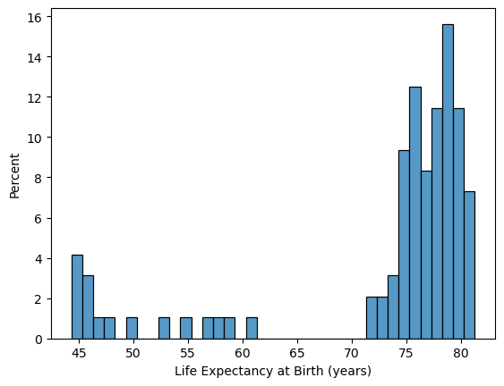

```python
ax1 = sns.histplot(x='LEAB', data=df, stat="percent", binwidth=1)
ax1.set_xlabel('Life Expectancy at Birth (years)');
```

Next the distribution of `GDP` was examined. The distribution is very right skewed where most of the values are on the left-hand side. This is almost the opposite of what was observed in the `LEAB` column.

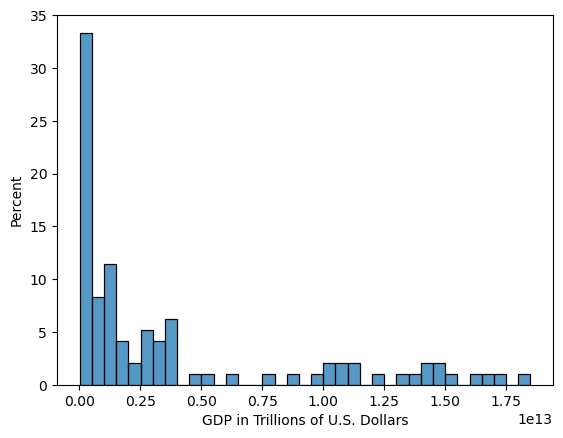

```python
ax2 = sns.histplot(x='GDP', data=df, stat="percent", binwidth=0.05e13)
ax2.set_xlabel('GDP in Trillions of U.S. Dollars');
```

The previous plots did not break up the data by countries, so the next task will be to find the average `LEAB` and `GDP` by country.

### Bar Plots

```python
dfMeans = df.drop("Year", axis=1).groupby("Country").mean().reset_index()
dfMeans
```

|  | Country | LEAB | GDP |
| --- | --- | --- | --- |
| 0 | Chile | 78.94375 | 1.697888e+11 |
| 1 | China | 74.26250 | 4.957714e+12 |
| 2 | Germany | 79.65625 | 3.094776e+12 |
| 3 | Mexico | 75.71875 | 9.766506e+11 |
| 4 | United States of America | 78.06250 | 1.407500e+13 |
| 5 | Zimbabwe | 50.09375 | 9.062580e+09 |

Now that they are broken down by `Country` and the average values for `LEAB` and `GDP` are created, bar plots showing the mean values for each variable are created below.

The first plot is Life Expectancy and all of the countries except for Zimbabwe have values in the mid-to-high 70s. This probably explains the skew in the distribution from before!

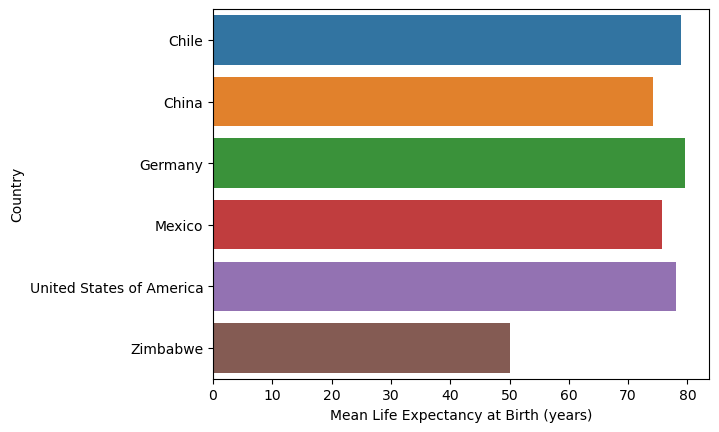

```python
ax3 = sns.barplot(y="Country", x="LEAB", data=dfMeans)
ax3.set_xlabel('Mean Life Expectancy at Birth (years)');
```

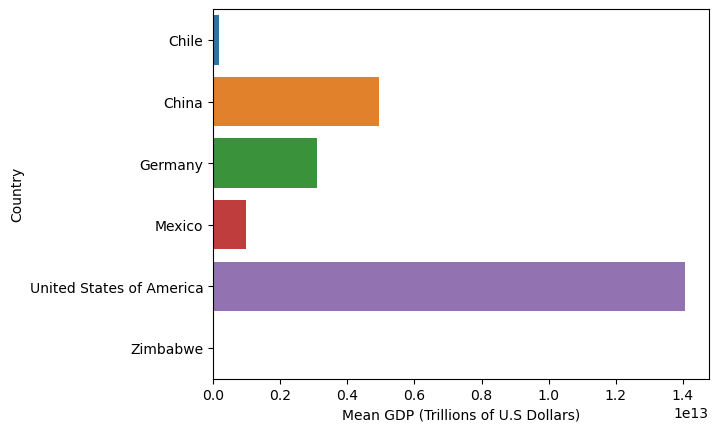

```python
ax4 = sns.barplot(y="Country", x="GDP", data=dfMeans)
ax4.set_xlabel('Mean GDP (Trillions of U.S Dollars)');
```

### Strip Plots

A newer method for showing distributions is the strip plot. Strip plots are useful because they show dot density around the values as well as distribution.

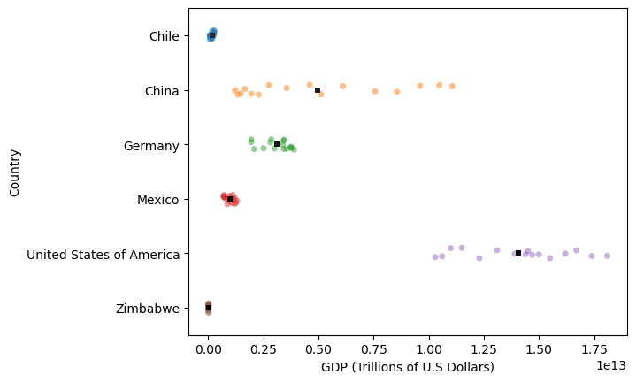

```python
ax5 = sns.stripplot(x="GDP", y="Country", data=df, hue='Country', alpha=0.5)
sns.stripplot(x='GDP', y='Country', data=dfMeans, hue='Country', palette='dark:black', marker='s')
ax5.set_xlabel('GDP (Trillions of U.S Dollars)')
plt.legend([],[], frameon=False);
```

The `LEAB` plot shows most of the countries except Zimbabwe have a fairly consistent life expectancy.

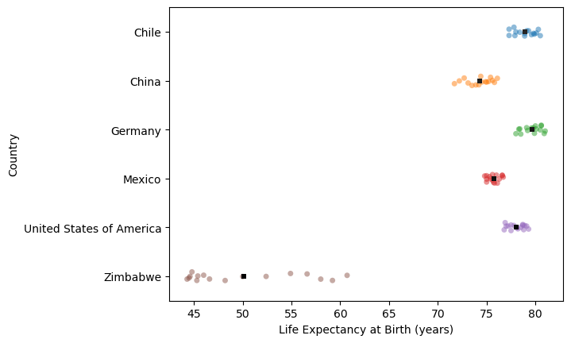

```python
ax6 = sns.stripplot(x="LEAB", y="Country", data=df, hue='Country', alpha=0.5)
sns.stripplot(x='LEAB', y='Country', data=dfMeans, hue='Country', palette='dark:black', marker='s')
ax6.set_xlabel('Life Expectancy at Birth (years)')
plt.legend([],[], frameon=False);
```

### Line Charts

Next the data will explore `LEAB` and `GDP` over the years through line charts. Below the countries are separated by colors and one can see that every country has been increasing their life expectancy between 2000-2015, but Zimbabwe has seen the greatest increase after a bit of a dip around 2004.

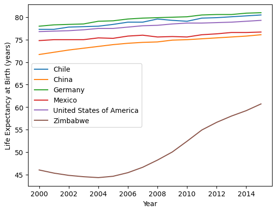

```python
ax7 = sns.lineplot(x='Year', y="LEAB", data=df, hue='Country')
ax7.set_ylabel('Life Expectancy at Birth (years)')
plt.legend();
```

Another aspect that was looked more into depth was the faceted line charts by Country. In the individual plots, each country has their own y axis, which makes it easier to compare the shape of their `LEAB` over the years without the same scale. This method makes it easier to see that Chile, and Mexico seemed to have dips in their life expectancy around the same time which could be looked into further.

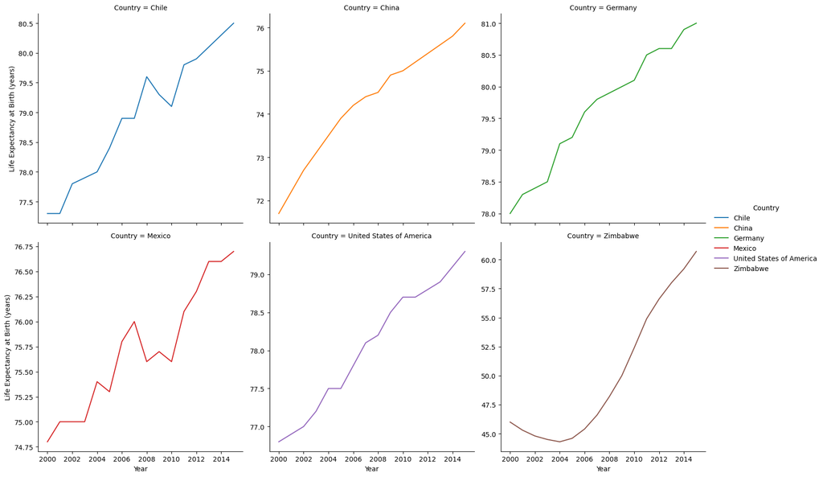

```python
ax8 = sns.relplot(
    data=df, x="Year", y="LEAB", col="Country", hue='Country',
    kind="line", col_wrap=3, facet_kws={'sharey': False}
)
ax8.set_ylabels('Life Expectancy at Birth (years)');
```

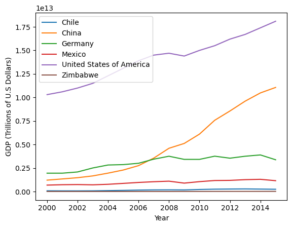

```python
ax9 = sns.lineplot(x='Year', y="GDP", data=df, hue='Country')
ax9.set_ylabel('GDP (Trillions of U.S Dollars)')
plt.legend();
```

Much like the breakdown of LEAB by country before, the plot below breaks out GDP by country. It is apparent that all of the countries have seen increases. In the chart above, the other country's GDP growth looked modest compared to China and the US, but all of the countries did experience growth from compared to the year 2000. This type of plotting proves useful since much of these nuances were lost when the y axis was shared among the countries. Also the seemingly linear changes were in reality was not as smooth for some of the countries.

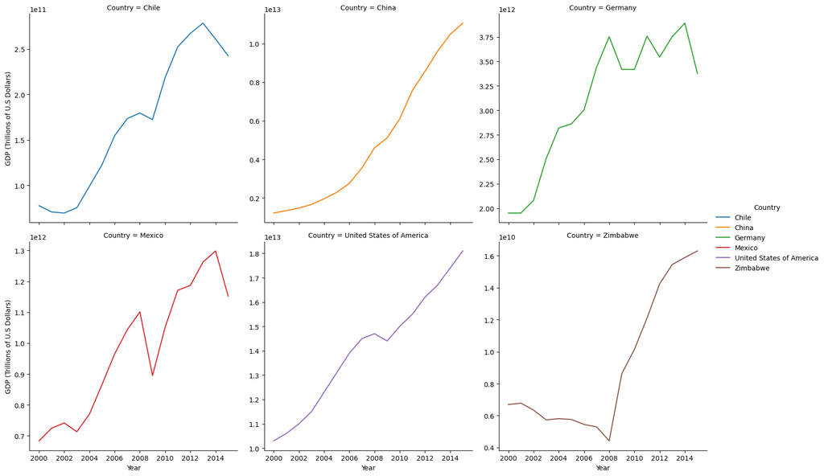

```python
ax10 = sns.relplot(
    data=df, x="Year", y="GDP", col="Country", hue='Country',
    kind="line", col_wrap=3, facet_kws={'sharey': False}
)
ax10.set_ylabels('GDP (Trillions of U.S Dollars)');
```

Is there a correlation between GDP and life expectancy of a country?

### Scatter Plots

The next two charts will explore the relationship between `GDP` and `LEAB`. In the chart below, it looks like the previous charts where GDP for Zimbabwe is staying flat, while their life expectancy is going up. For the other countries they seem to exhibit a rise in life expectancy as GDP goes up. The US and China seem to have very similar slopes in their relationship between GDP and life expectancy.

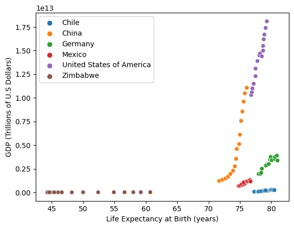

```python
ax11 = sns.scatterplot(x='LEAB', y="GDP", data=df, hue='Country')
ax11.set_xlabel('Life Expectancy at Birth (years)')
ax11.set_ylabel('GDP (Trillions of U.S Dollars)')
plt.legend();
```

Like the previous plots, countries are broken out into each scatter plot by facets. Looking at the individual countries, most countries like the US, Mexico and Zimbabwe have linear relationships between GDP and life expectancy. China on the other hand has a slightly exponential curve, and Chile's looks a bit logarithmic. In general though one can see an increase in GDP and life expectancy, exhibiting a positive correlation.

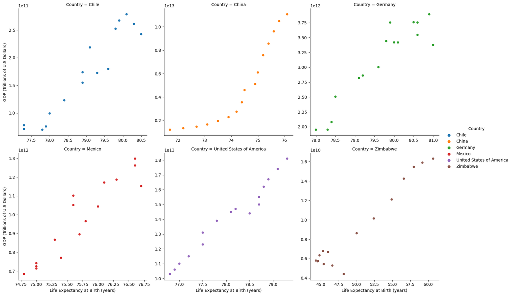

```python
ax12 = sns.relplot(
    data=df, x="LEAB", y="GDP", col="Country", hue='Country',
    kind="scatter", col_wrap=3, facet_kws={'sharex': False, 'sharey': False}
)
ax12.set_xlabels('Life Expectancy at Birth (years)')
ax12.set_ylabels('GDP (Trillions of U.S Dollars)');
```

## Conclusions

This project was able to make quite a few data visualizations with the data even though there were only 96 rows and 4 columns.

The project was also able to answer some of the questions posed in the beginning:

- Has life expectancy increased over time in the six nations?
  - Yes with Zimbabwe having the greatest increase.
- Has GDP increased over time in the six nations?
  - GDP has also increased for all countries in our list, especially for China.
- Is there a correlation between GDP and life expectancy of a country?
  - Yes there is a positive correlation between GDP and life expectancy for countries in our list.
- What is the average life expectancy in these nations?
  - Average life expectancy was between mid to high 70s for the countries except for Zimbabwe which was 50.
- What is the distribution of that life expectancy?
  - The life expectancy had a leftward skew, and most of the observations were on the right side.

## Important Notes

### Links

[1] Cong, Lin and Gao, Haoyu and Ponticelli, Jacopo and Yang, Xiaoguang, Credit Allocation under Economic Stimulus: Evidence from China (November 1, 2018). Chicago Booth Research Paper No. 17-19, Available at SSRN: https://ssrn.com/abstract=2862101 or http://dx.doi.org/10.2139/ssrn.2862101

[2] Moyo, Nicky and Besada, Hany, Zimbabwe in Crisis: Mugabe's Policies and Failures (October 18, 2008). The Centre for International Governance Innovation Technical Paper No. 38 , Available at SSRN: https://ssrn.com/abstract=1286683 or http://dx.doi.org/10.2139/ssrn.1286683